# Final Project: The Olympics

## France: Womens Events

- Marie-Jos Juliana Prec (Hontas-) and Flicia Michele Sylviane Ballanger (-Vetu) with 3 Medals Total
  - Filicia - Cycling Womens Sprint: 2 Gold

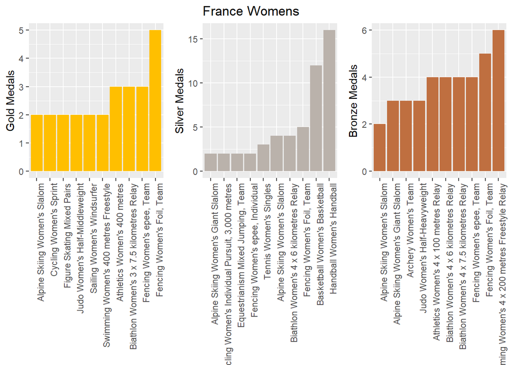

- These maps will give an overview of Medal dispursement throughout the different countries.

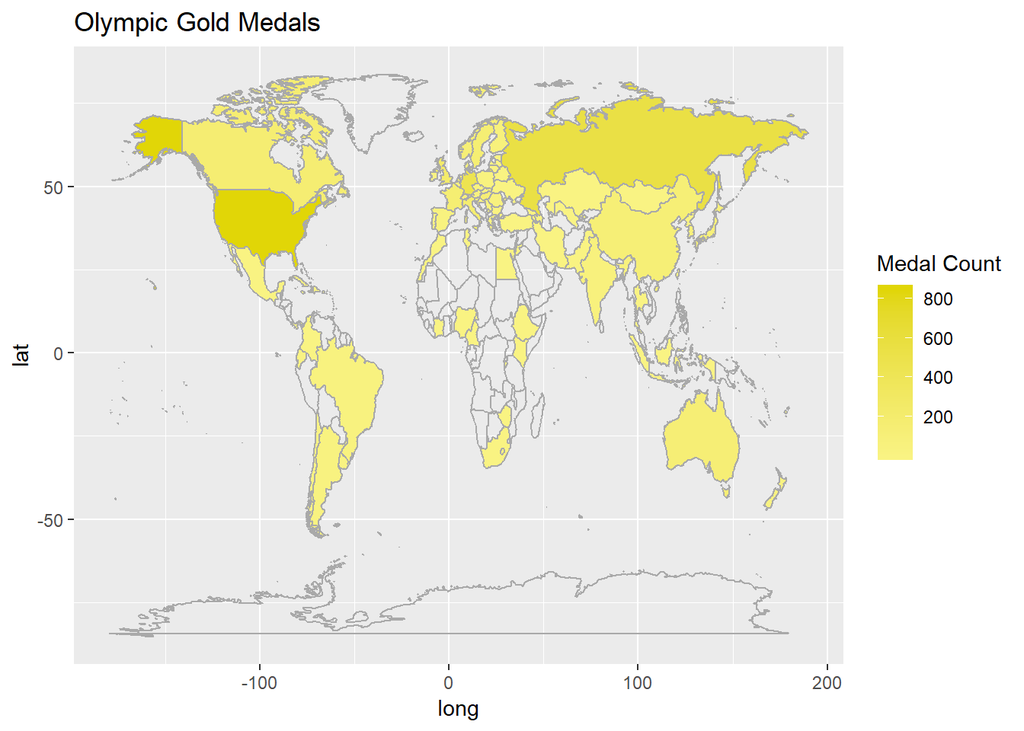

```r
library(maps)
world <- map_data("world")
  # World Map of Gold Medals
medals.gold = medals_country %>% filter(Medal %in% "Gold")
map.gold = medals.gold %>% left_join(world, by = "region")
map.gold %>% ggplot() + geom_polygon(aes(x = long, y = lat, group=group, fill = Num_Medals)) + scale_fill_gradient(low = "#f9f383", high = "#e1d607", name = "Medal Count") + geom_path(data = world, aes(x = long, y = lat, group = group), color = "dark grey") + ggtitle("Olympic Gold Medals")
```

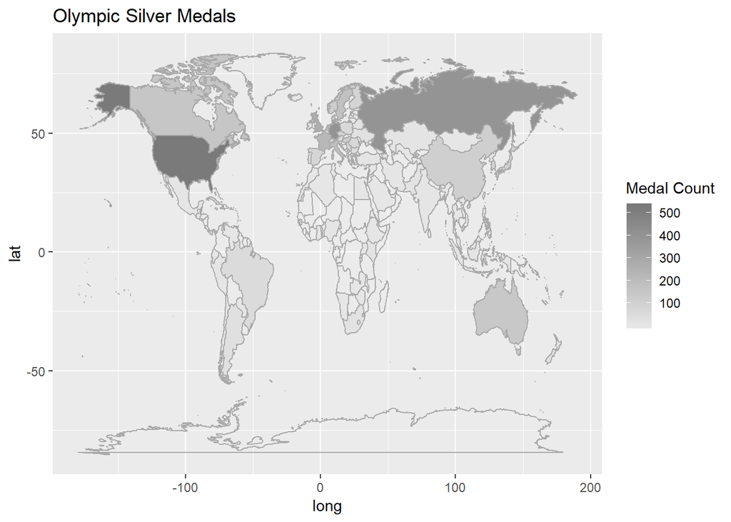

```r
  # World Map of Silver Medals
medals.silver = medals_country %>% filter(Medal %in% "Silver")
map.silver = medals.silver %>% left_join(world, by = "region")
map.silver %>% ggplot() + geom_polygon(aes(x = long, y = lat, group=group, fill = Num_Medals)) + scale_fill_gradient(low = "#e6e6e6", high = "#7a7a7a", name = "Medal Count") + geom_path(data = world, aes(x = long, y = lat, group = group), color = "dark grey") + ggtitle("Olympic Silver Medals")
```

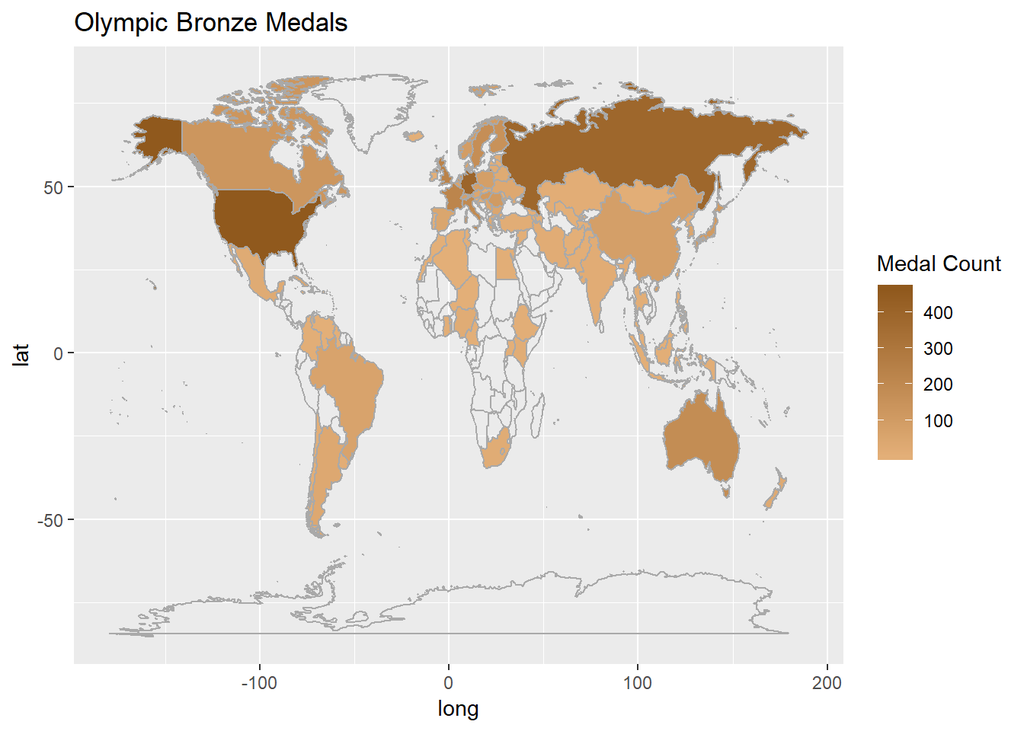

```r
# World Map of Bronze Medals
medals.bronze = medals_country %>% filter(Medal %in% "Bronze")
map.bronze = medals.bronze %>% left_join(world, by = "region")
map.bronze %>% ggplot() + geom_polygon(aes(x = long, y = lat, group=group, fill = Num_Medals)) + scale_fill_gradient(low = "#e3af78", high = "#90591d", name = "Medal Count") + geom_path(data = world, aes(x = long, y = lat, group = group), color = "dark grey") + ggtitle("Olympic Bronze Medals")
```

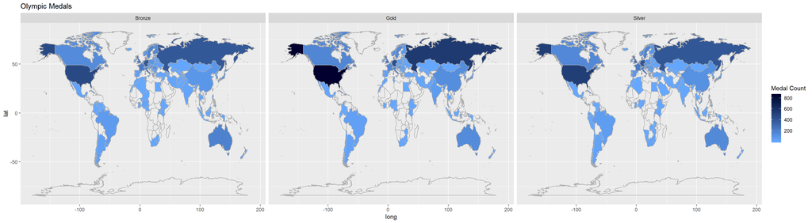

```r
# Facet maps of gold, silver, and bronze medals in the world:
map.medals = medals_country %>% left_join(world, by = "region")
map.medals %>% ggplot() + geom_polygon(aes(x = long, y = lat, group=group, fill = Num_Medals)) + geom_path(data = world, aes(x = long, y = lat, group = group), color = "dark grey") + ggtitle("Olympic Medals") + facet_wrap(~Medal) + scale_fill_gradient(low = "#66a8ff", high = "#02002e", name = "Medal Count")
```

# Follow Up

- The data set seemed to match with expectations that the more major countries end up with a larger quantity.
- Most variables in the dataset seemed to have the correct variable types. *We found for the athletes group in our first analysis that it did not include all the events for some reason and had to filter from a different group we created.

# Findings

- We found plausible relationships between countries and specific sports with visual aid. With more tiem this would have become a more interesting topic to look into for every country.Possibly geographic locations play a role? *Over the years the average age of athletes has leveled off and the gender gap is continually closing in the amount of athletes competing.

# Overall

This data set was fairly simple to clean and reshape allowing us to work with it. We looked deeper into the top 5 countries and at a broad overview for the data set. It could be interesting to explore some of our finding and find possible causes, and with more time that would be our next goal. Somethings we could have done better was possibly pick out a recent decade or split the data into decades; as some events no longer exist, and many things can change over the years; from ages to gender ratios.